# Lab 7 — MLR with Dummy Variable, Interaction & Model Selection

# Load Packages

```r
# Uncomment to install if needed:
# install.packages("MASS")
# install.packages("dplyr")
# install.packages("ggplot2")
# install.packages("car")
# install.packages("glmnet")   # only needed for Extra Practice

library(MASS)     # Boston dataset
library(dplyr)    # data manipulation
library(ggplot2)  # visualization
library(car)      # VIF for multicollinearity
library(glmnet)   # LASSO (Extra Practice)
```

# Prepare Data: Create a Dummy Variable

## What is a dummy variable?

A **dummy variable** converts a categorical label into a number (0 or 1) so it can be used in a regression equation.

- **0** = reference group (the baseline)
- **1** = the other group

The regression coefficient on the dummy tells you: *“How much does Y change when you move from group 0 to group 1, holding everything else constant?”*

## Create `high_crime` from `crim`

`crim` is a continuous variable (crime rate per capita). We split it at the **median** to create two groups:

- `"Low Crime"` → crime rate ≤ median → **reference group (0)**
- `"High Crime"` → crime rate > median → **dummy group (1)**

```r
data(Boston)

# Step 1: find the median crime rate
median_crim <- median(Boston$crim)
paste("Median crime rate:", round(median_crim, 3))
```

```
## [1] "Median crime rate: 0.257"
```

```r
# Step 2: create the dummy variable using dplyr
Boston <- Boston %>%
  mutate(high_crime = ifelse(crim > median_crim, "High Crime", "Low Crime"),
         high_crime = factor(high_crime, levels = c("Low Crime", "High Crime")))

# Step 3: check the split
table(Boston$high_crime)
```

```
##
##  Low Crime High Crime
##        253        253
```

```r
# Step 4: compare mean home value across groups
tapply(Boston$medv, Boston$high_crime, mean)
```

```
##  Low Crime High Crime
##   24.94941   20.11621
```

## Explore: Boxplot by Crime Group

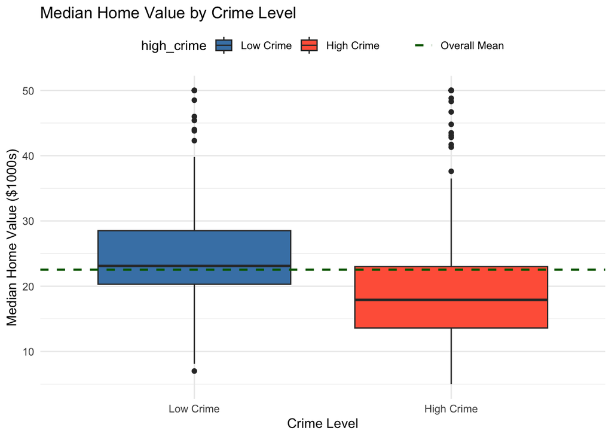

```r
ggplot(Boston, aes(x = high_crime, y = medv, fill = high_crime)) +
  geom_boxplot() +
  scale_fill_manual(values = c("Low Crime" = "steelblue", "High Crime" = "tomato")) +
  geom_hline(aes(yintercept = mean(medv), linetype = "Overall Mean"),
             color = "darkgreen", linewidth = 0.8) +
  scale_linetype_manual(name = "", values = "dashed") +
  labs(title = "Median Home Value by Crime Level",
       x     = "Crime Level",
       y     = "Median Home Value ($1000s)") +
  theme_minimal() +
  theme(legend.position = "top")
```

**Question 1:** Based on the boxplot, how large is the difference in median home value between Low Crime and High Crime tracts? Do you expect this difference to remain significant after controlling for other predictors like room size and school quality?

# Part 1: MLR with a Dummy Variable

## The Model Equation

We use three predictors:

- `rm` — average number of rooms
- `ptratio` — pupil-teacher ratio
- `high_crime` — our dummy variable (Low Crime = 0, High Crime = 1)

> **Why not `lstat`?** `lstat` (% lower-status population) is highly correlated with `high_crime` — both measure neighborhood disadvantage. Including both causes **over-controlling**: `lstat` absorbs the crime effect and can flip the sign of `high_crime` from negative to positive. We exclude `lstat` here so the dummy coefficient tells the crime story clearly.

$$\hat{\text{medv}} = \beta_0 + \beta_1
\cdot \text{rm} + \beta_2 \cdot \text{ptratio} + \beta_3 \cdot
\mathbf{1}[\text{High Crime}]$$

**What the dummy does to the equation:**

When `high_crime = "Low Crime"` (dummy = 0):

$$\hat{\text{medv}} = \beta_0 + \beta_1
\cdot \text{rm} + \beta_2 \cdot \text{ptratio}$$

When `high_crime = "High Crime"` (dummy = 1):

$$\hat{\text{medv}} = (\beta_0 + \beta_3)
+ \beta_1 \cdot \text{rm} + \beta_2 \cdot \text{ptratio}$$

$\beta_3$ is the **intercept shift** — the estimated gap in home value between the two groups, all else equal.

## Fit the Model

```r
model_dummy <- lm(medv ~ rm + ptratio + high_crime, data = Boston)
summary(model_dummy)
```

```
##
## Call:
## lm(formula = medv ~ rm + ptratio + high_crime, data = Boston)
##
## Residuals:
##     Min      1Q  Median      3Q     Max
## -16.650  -3.207   0.028   2.314  40.454
##
## Coefficients:
##                      Estimate Std. Error t value Pr(>|t|)
## (Intercept)           -2.8009     4.1468  -0.675 0.499710
## rm                     7.6125     0.4105  18.544  < 2e-16 ***
## ptratio               -1.1687     0.1360  -8.591  < 2e-16 ***
## high_crimeHigh Crime  -1.8803     0.5568  -3.377 0.000791 ***
## ---
## Signif. codes:  0 '***' 0.001 '**' 0.01 '*' 0.05 '.' 0.1 ' ' 1
##
## Residual standard error: 6.042 on 502 degrees of freedom
## Multiple R-squared:  0.571,  Adjusted R-squared:  0.5684
## F-statistic: 222.7 on 3 and 502 DF,  p-value: < 2.2e-16
```

## Visualize: Parallel Regression Lines

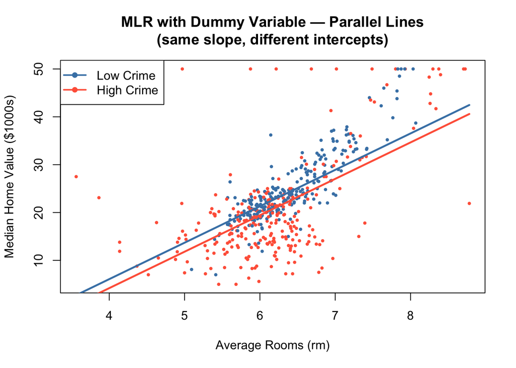

```r
ptratio_mean <- mean(Boston$ptratio)
rm_seq       <- seq(min(Boston$rm), max(Boston$rm), length.out = 200)

pred_low  <- predict(model_dummy,
  newdata = data.frame(rm = rm_seq, ptratio = ptratio_mean,
                       high_crime = factor("Low Crime",  levels = c("Low Crime","High Crime"))))
pred_high <- predict(model_dummy,
  newdata = data.frame(rm = rm_seq, ptratio = ptratio_mean,
                       high_crime = factor("High Crime", levels = c("Low Crime","High Crime"))))

plot(Boston$rm, Boston$medv,
     col  = ifelse(Boston$high_crime == "High Crime", "tomato", "steelblue"),
     pch  = 16, cex = 0.6,
     xlab = "Average Rooms (rm)",
     ylab = "Median Home Value ($1000s)",
     main = "MLR with Dummy Variable — Parallel Lines\n(same slope, different intercepts)")
lines(rm_seq, pred_low,  col = "steelblue", lwd = 2.5)
lines(rm_seq, pred_high, col = "tomato",    lwd = 2.5)
legend("topleft", legend = c("Low Crime", "High Crime"),
       col = c("steelblue", "tomato"), pch = 16, lwd = 2)
```

> **Notice:** The lines are **parallel** — the dummy variable only shifts the intercept up or down. It assumes the *effect of `rm` on home value is the same* in both groups. We test this assumption in Part 2.

**Question 2:** Interpret the dummy coefficient `high_crimeHigh Crime`:

1. What is the estimated difference in home value between High Crime and Low Crime tracts, holding all other predictors fixed?
2. Is the coefficient statistically significant? What does the p-value tell you?

# Part 2: Adding an Interaction Term

## Why Add an Interaction?

The dummy-only model forces the two groups to have the **same slope**. But maybe the value of an extra room depends on whether the neighborhood is safe or not.

An **interaction term** `rm × high_crime` lets each group have its **own slope**.

$$\hat{\text{medv}} = \beta_0 + \beta_1
\cdot \text{rm} + \beta_2 \cdot \text{ptratio} + \beta_3 \cdot D +
\beta_4 \cdot (\text{rm} \times D)$$

Where $D = \mathbf{1}[\text{High Crime}]$

| Group | Intercept | Slope of `rm` |
| --- | --- | --- |
| Low Crime (D = 0) | $\beta_0$ | $\beta_1$ |
| High Crime (D = 1) | $\beta_0 + \beta_3$ | $\beta_1 + \beta_4$ |

$\beta_4$ = how much the slope of `rm` **changes** in High Crime areas.

> In R, `rm * high_crime` is shorthand for `rm + high_crime + rm:high_crime` (main effects + interaction).

## Fit the Interaction Model

```r
model_interact <- lm(medv ~ rm * high_crime + ptratio, data = Boston)
summary(model_interact)
```

```
##
## Call:
## lm(formula = medv ~ rm * high_crime + ptratio, data = Boston)
##
## Residuals:
##     Min      1Q  Median      3Q     Max
## -15.226  -3.073  -0.105   2.406  39.109
##
## Coefficients:
##                         Estimate Std. Error t value Pr(>|t|)
## (Intercept)             -18.8257     5.5453  -3.395 0.000741 ***
## rm                       10.0203     0.6941  14.436  < 2e-16 ***
## high_crimeHigh Crime     20.1548     5.1965   3.879 0.000119 ***
## ptratio                  -1.1336     0.1340  -8.458 2.99e-16 ***
## rm:high_crimeHigh Crime  -3.4891     0.8183  -4.264 2.40e-05 ***
## ---
## Signif. codes:  0 '***' 0.001 '**' 0.01 '*' 0.05 '.' 0.1 ' ' 1
##
## Residual standard error: 5.941 on 501 degrees of freedom
## Multiple R-squared:  0.586,  Adjusted R-squared:  0.5827
## F-statistic: 177.3 on 4 and 501 DF,  p-value: < 2.2e-16
```

## Extract & Compare Slopes

```r
beta <- coef(model_interact)

slope_low  <- beta["rm"]
slope_high <- beta["rm"] + beta["rm:high_crimeHigh Crime"]

# Print the slopes as a clean data frame
data.frame(
  Group             = c("Low Crime", "High Crime", "Difference (β4)"),
  Slope_of_rm       = round(c(slope_low, slope_high, beta["rm:high_crimeHigh Crime"]), 3),
  row.names         = NULL
)
```

```
##             Group Slope_of_rm
## 1       Low Crime      10.020
## 2      High Crime       6.531
## 3 Difference (β4)      -3.489
```

## Test: Does the Interaction Improve the Model?

We use an **ANOVA F-test** to formally compare:

- **Model 1** (`model_dummy`): parallel lines — same slope for both groups
- **Model 2** (`model_interact`): different slopes — interaction allowed

```r
anova(model_dummy, model_interact)
```

```
## Analysis of Variance Table
##
## Model 1: medv ~ rm + ptratio + high_crime
## Model 2: medv ~ rm * high_crime + ptratio
##   Res.Df   RSS Df Sum of Sq      F    Pr(>F)
## 1    502 18325
## 2    501 17684  1     641.8 18.183 2.399e-05 ***
## ---
## Signif. codes:  0 '***' 0.001 '**' 0.01 '*' 0.05 '.' 0.1 ' ' 1
```

**How to read the output:** If the p-value is < 0.05, the interaction significantly improves the model — the slopes really are different between groups.

## Visualize: Non-Parallel Lines

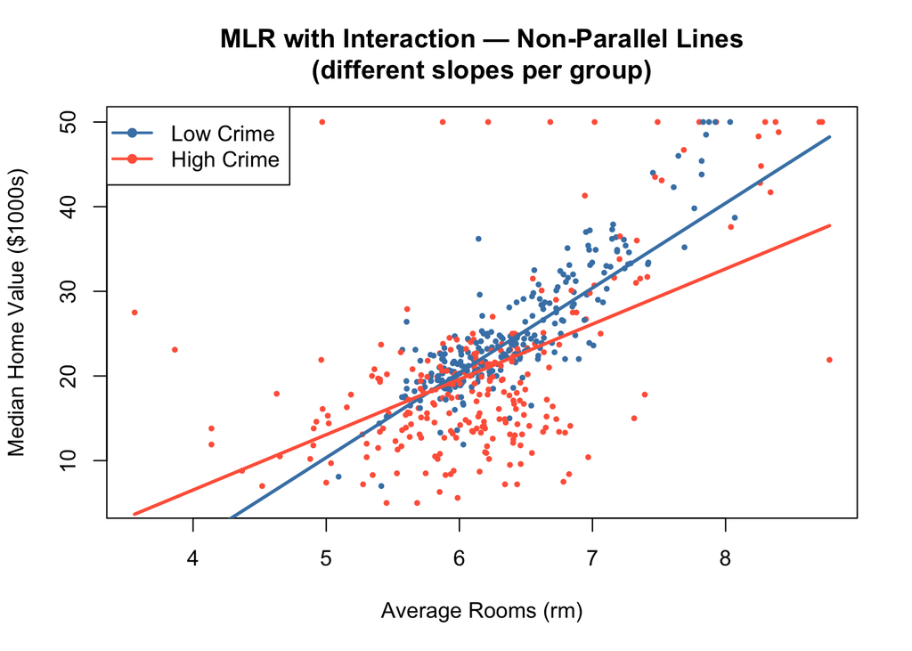

```r
pred_low_int  <- predict(model_interact,
  newdata = data.frame(rm = rm_seq, ptratio = ptratio_mean,
                       high_crime = factor("Low Crime",  levels = c("Low Crime","High Crime"))))
pred_high_int <- predict(model_interact,
  newdata = data.frame(rm = rm_seq, ptratio = ptratio_mean,
                       high_crime = factor("High Crime", levels = c("Low Crime","High Crime"))))

plot(Boston$rm, Boston$medv,
     col  = ifelse(Boston$high_crime == "High Crime", "tomato", "steelblue"),
     pch  = 16, cex = 0.6,
     xlab = "Average Rooms (rm)",
     ylab = "Median Home Value ($1000s)",
     main = "MLR with Interaction — Non-Parallel Lines\n(different slopes per group)")
lines(rm_seq, pred_low_int,  col = "steelblue", lwd = 2.5)
lines(rm_seq, pred_high_int, col = "tomato",    lwd = 2.5)
legend("topleft", legend = c("Low Crime", "High Crime"),
       col = c("steelblue", "tomato"), pch = 16, lwd = 2)
```

**Question 3:**

1. Is the interaction term `rm:high_crimeHigh Crime` statistically significant?
2. In which group does each additional room add more home value?
3. What does the ANOVA F-test tell you — is the interaction worth adding?

# Part 3: Checking Regression Assumptions

Before trusting any model, we must check that the five key assumptions hold. We use `model_interact` as our working model.

## The Four Diagnostic Plots

R’s `plot()` function gives us four diagnostic plots in one go:

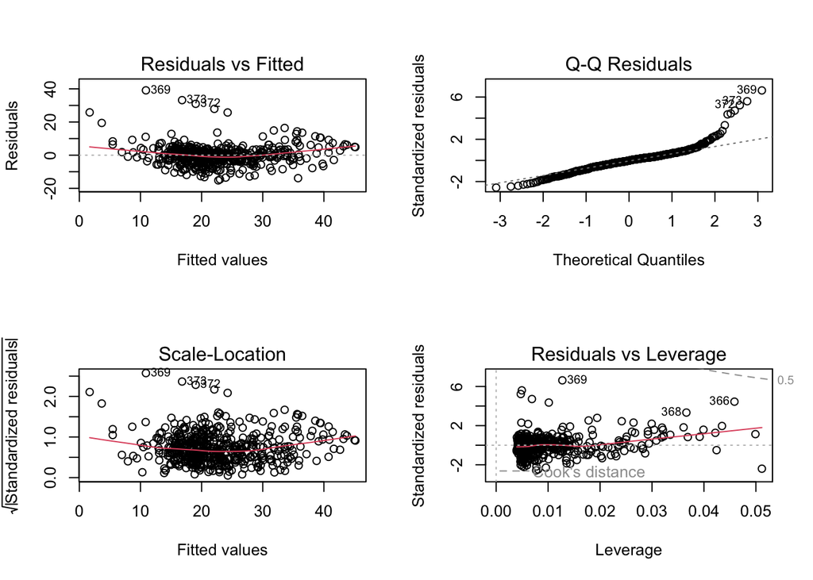

```r
par(mfrow = c(2, 2))
plot(model_interact)
```

```r
par(mfrow = c(1, 1))
```

## Assumption 1 — Linearity

**Plot:** Residuals vs Fitted (top-left)

**What to look for:** A flat red line with random scatter — no curves or U-shapes.

A curved pattern means the relationship is not linear and you may need to transform a predictor (e.g., log, square root).

## Assumption 2 — Normality of Residuals

**Plot:** Normal Q-Q (top-right)

**What to look for:** Points falling close to the diagonal dashed line.

Heavy tails (points curving away at the ends) or an S-shape suggest the residuals are not normally distributed. This affects the reliability of p-values.

## Assumption 3 — Equal Variance (Homoscedasticity)

**Plot:** Scale-Location (bottom-left)

**What to look for:** A flat horizontal red line with evenly spread points.

A funnel shape (spread increasing as fitted values increase) means **heteroscedasticity** — your standard errors are unreliable.

## Assumption 4 — No Influential Observations

**Plot:** Residuals vs Leverage (bottom-right)

**What to look for:** Points outside the Cook’s distance dashed lines are influential — they have an outsized effect on the model coefficients.

## Assumption 5 — No Multicollinearity

Multicollinearity means predictors are highly correlated with each other, making coefficients unstable and hard to interpret. We check using **VIF (Variance Inflation Factor)**.

```r
# VIF > 5 = concern; VIF > 10 = serious problem
vif(model_interact)
```

```
##            rm    high_crime       ptratio rm:high_crime
##      3.402863     96.776997      1.204386     94.630198
```

```r
# Correlation matrix of numeric predictors
cor_vars <- Boston[, c("rm", "ptratio", "crim")]
round(cor(cor_vars), 3)
```

```
##             rm ptratio   crim
## rm       1.000  -0.356 -0.219
## ptratio -0.356   1.000  0.290
## crim    -0.219   0.290  1.000
```

> **Note:** Interaction terms naturally produce high VIF — this is expected and not a real problem. Focus on the VIF of the main effects (`rm`, `ptratio`).

**Question 4:** Based on all five diagnostic checks:

1. Which assumptions appear to be satisfied?
2. Which assumptions may be violated? What evidence from the plots supports this?

# Part 4: Model Selection — Stepwise

We now have a model with a dummy and interaction. But should we include more predictors from the full Boston dataset? **Stepwise selection** automatically finds the best combination of predictors using AIC.

## What is AIC?

**AIC (Akaike Information Criterion)** measures model quality — it rewards good fit and penalizes complexity. **Lower AIC = better model.**

At each step, the algorithm tries adding or removing one predictor and picks the move that most reduces AIC. It stops when no single change improves AIC further.

## Prepare Full and Null Models

```r
# Full model: all available predictors + our dummy + interaction
# We exclude original crim (replaced by high_crime)
model_full <- lm(medv ~ zn + indus + chas + nox + rm + age +
                   dis + rad + tax + ptratio + black + lstat +
                   high_crime + rm:high_crime,
                 data = Boston)

# Null model: intercept only (no predictors) — starting point for forward selection
model_null <- lm(medv ~ 1, data = Boston)
```

## Forward Stepwise

**Idea:** Start with nothing, add one predictor at a time — only keep it if it reduces AIC.

```r
model_forward <- step(model_null,
                      scope     = list(lower = model_null, upper = model_full),
                      direction = "forward",
                      trace     = FALSE)   # set trace = TRUE to see each step

summary(model_forward)
```

```
##
## Call:
## lm(formula = medv ~ lstat + rm + ptratio + dis + nox + chas +
##     black + high_crime + rm:high_crime, data = Boston)
##
## Residuals:
##      Min       1Q   Median       3Q      Max
## -12.7912  -2.7501  -0.8019   1.7720  26.4098
##
## Coefficients:
##                           Estimate Std. Error t value Pr(>|t|)
## (Intercept)              19.032128   5.843334   3.257 0.001203 **
## lstat                    -0.536201   0.046446 -11.545  < 2e-16 ***
## rm                        6.366589   0.610382  10.430  < 2e-16 ***
## ptratio                  -1.010705   0.110068  -9.183  < 2e-16 ***
## dis                      -1.075467   0.160299  -6.709 5.36e-11 ***
## nox                     -22.147050   3.543335  -6.250 8.83e-10 ***
## chas                      2.988106   0.846694   3.529 0.000456 ***
## black                     0.010572   0.002579   4.099 4.85e-05 ***
## high_crimeHigh Crime     22.552226   4.147465   5.438 8.49e-08 ***
## rm:high_crimeHigh Crime  -3.226123   0.651862  -4.949 1.02e-06 ***
## ---
## Signif. codes:  0 '***' 0.001 '**' 0.01 '*' 0.05 '.' 0.1 ' ' 1
##
## Residual standard error: 4.717 on 496 degrees of freedom
## Multiple R-squared:  0.7416, Adjusted R-squared:  0.7369
## F-statistic: 158.2 on 9 and 496 DF,  p-value: < 2.2e-16
```

## Backward Stepwise

**Idea:** Start with all predictors, remove one at a time — only remove it if AIC improves.

```r
model_backward <- step(model_full,
                       direction = "backward",
                       trace     = FALSE)

summary(model_backward)
```

```
##
## Call:
## lm(formula = medv ~ zn + chas + nox + rm + dis + rad + tax +
##     ptratio + black + lstat + high_crime + rm:high_crime, data = Boston)
##
## Residuals:
##      Min       1Q   Median       3Q      Max
## -12.8351  -2.7379  -0.6455   1.8815  25.8731
##
## Coefficients:
##                           Estimate Std. Error t value Pr(>|t|)
## (Intercept)              24.594826   6.180122   3.980 7.94e-05 ***
## zn                        0.025713   0.014270   1.802 0.072179 .
## chas                      2.832903   0.843490   3.359 0.000844 ***
## nox                     -20.695805   3.743916  -5.528 5.26e-08 ***
## rm                        5.643432   0.665139   8.485 2.55e-16 ***
## dis                      -1.260336   0.185753  -6.785 3.34e-11 ***
## rad                       0.170016   0.061745   2.754 0.006114 **
## tax                      -0.009262   0.003368  -2.750 0.006177 **
## ptratio                  -0.965282   0.127710  -7.558 2.00e-13 ***
## black                     0.010921   0.002629   4.155 3.84e-05 ***
## lstat                    -0.541561   0.046398 -11.672  < 2e-16 ***
## high_crimeHigh Crime     18.357118   4.443593   4.131 4.24e-05 ***
## rm:high_crimeHigh Crime  -2.592147   0.698091  -3.713 0.000228 ***
## ---
## Signif. codes:  0 '***' 0.001 '**' 0.01 '*' 0.05 '.' 0.1 ' ' 1
##
## Residual standard error: 4.683 on 493 degrees of freedom
## Multiple R-squared:  0.7469, Adjusted R-squared:  0.7408
## F-statistic: 121.3 on 12 and 493 DF,  p-value: < 2.2e-16
```

## Both-Direction Stepwise

**Idea:** At each step, try both adding AND removing — pick whichever improves AIC most.

```r
model_both <- step(model_full,
                   direction = "both",
                   trace     = FALSE)

summary(model_both)
```

```
##
## Call:
## lm(formula = medv ~ zn + chas + nox + rm + dis + rad + tax +
##     ptratio + black + lstat + high_crime + rm:high_crime, data = Boston)
##
## Residuals:
##      Min       1Q   Median       3Q      Max
## -12.8351  -2.7379  -0.6455   1.8815  25.8731
##
## Coefficients:
##                           Estimate Std. Error t value Pr(>|t|)
## (Intercept)              24.594826   6.180122   3.980 7.94e-05 ***
## zn                        0.025713   0.014270   1.802 0.072179 .
## chas                      2.832903   0.843490   3.359 0.000844 ***
## nox                     -20.695805   3.743916  -5.528 5.26e-08 ***
## rm                        5.643432   0.665139   8.485 2.55e-16 ***
## dis                      -1.260336   0.185753  -6.785 3.34e-11 ***
## rad                       0.170016   0.061745   2.754 0.006114 **
## tax                      -0.009262   0.003368  -2.750 0.006177 **
## ptratio                  -0.965282   0.127710  -7.558 2.00e-13 ***
## black                     0.010921   0.002629   4.155 3.84e-05 ***
## lstat                    -0.541561   0.046398 -11.672  < 2e-16 ***
## high_crimeHigh Crime     18.357118   4.443593   4.131 4.24e-05 ***
## rm:high_crimeHigh Crime  -2.592147   0.698091  -3.713 0.000228 ***
## ---
## Signif. codes:  0 '***' 0.001 '**' 0.01 '*' 0.05 '.' 0.1 ' ' 1
##
## Residual standard error: 4.683 on 493 degrees of freedom
## Multiple R-squared:  0.7469, Adjusted R-squared:  0.7408
## F-statistic: 121.3 on 12 and 493 DF,  p-value: < 2.2e-16
```

## Compare All Stepwise Results

```r
stepwise_compare <- data.frame(
  Method    = c("Forward", "Backward", "Both"),
  Adj_R2    = round(c(summary(model_forward)$adj.r.squared,
                      summary(model_backward)$adj.r.squared,
                      summary(model_both)$adj.r.squared), 4),
  AIC       = round(c(AIC(model_forward), AIC(model_backward), AIC(model_both)), 2),
  BIC       = round(c(BIC(model_forward), BIC(model_backward), BIC(model_both)), 2),
  Num_Coefs = c(length(coef(model_forward)),
                length(coef(model_backward)),
                length(coef(model_both)))
)
stepwise_compare
```

```
##     Method Adj_R2     AIC     BIC Num_Coefs
## 1  Forward 0.7369 3017.71 3064.20        10
## 2 Backward 0.7408 3013.18 3072.35        13
## 3     Both 0.7408 3013.18 3072.35        13
```

**Question 5:**

1. Which method produces the lowest AIC?
2. Is the `high_crime` dummy retained? Is the interaction term `rm:high_crime` retained?

# Final Model Comparison

Let’s compare all the models we built from scratch:

```r
all_models <- list(
  "1. Dummy only"          = model_dummy,
  "2. Dummy + Interaction" = model_interact,
  "3. Full model (OLS)"    = model_full,
  "4. Stepwise (backward)" = model_backward
)

comparison <- data.frame(
  Model     = names(all_models),
  Adj_R2    = sapply(all_models, function(m) round(summary(m)$adj.r.squared, 4)),
  AIC       = sapply(all_models, function(m) round(AIC(m), 2)),
  BIC       = sapply(all_models, function(m) round(BIC(m), 2)),
  Num_Coefs = sapply(all_models, function(m) length(coef(m))),
  row.names = NULL
)
comparison
```

```
##                    Model Adj_R2     AIC     BIC Num_Coefs
## 1          1. Dummy only 0.5684 3262.26 3283.39         4
## 2 2. Dummy + Interaction 0.5827 3246.22 3271.58         5
## 3    3. Full model (OLS) 0.7400 3016.61 3084.24        15
## 4 4. Stepwise (backward) 0.7408 3013.18 3072.35        13
```

**Question 6 — Final Reflection:**

1. Which model has the best balance of fit and simplicity (consider Adj R², AIC, BIC together)?
2. If you had to recommend one model to a policy maker, which would you choose and why?

# ⭐ Extra Practice: LASSO

> This section introduces an alternative model selection method. It is optional but highly recommended if you want to go beyond stepwise.

## What is LASSO?

**LASSO** (Least Absolute Shrinkage and Selection Operator) is a smarter way to select predictors. Instead of adding/removing one at a time like stepwise, LASSO shrinks **all** coefficients simultaneously — and pushes the less important ones all the way to **exactly zero**.

Think of it like a **budget constraint on your coefficients.** The larger the penalty (controlled by $\lambda$), the tighter the budget, and the more coefficients get cut.

$$\text{Minimize: }
\underbrace{RSS}_{\text{fit}} + \underbrace{\lambda \sum_{j=1}^{p}
|\beta_j|}_{\text{penalty}}$$

| $\lambda$ value | Effect |
| --- | --- |
| $\lambda = 0$ | No penalty → same as regular OLS |
| $\lambda$ increases | Coefficients shrink toward zero |
| $\lambda$ very large | All coefficients = 0 |

The key: unlike OLS or ridge regression, LASSO can shrink coefficients to **exactly zero** — so it automatically selects which predictors to keep.

## Step 1: Prepare the Data Matrix

LASSO uses the `glmnet` package, which requires a **numeric matrix** instead of a formula. We use `model.matrix()` to create it.

```r
# model.matrix() converts the formula into a numeric matrix
# [, -1] removes the intercept column (glmnet adds its own)
x <- model.matrix(medv ~ zn + indus + chas + nox + rm + age +
                    dis + rad + tax + ptratio + black + lstat +
                    high_crime + rm:high_crime,
                  data = Boston)[, -1]

y <- Boston$medv

# Quick check of the data dimensions
data.frame(
  Item  = c("Number of predictors", "Number of observations"),
  Value = c(ncol(x), nrow(x)),
  row.names = NULL
)
```

```
##                     Item Value
## 1   Number of predictors    14
## 2 Number of observations   506
```

## Step 2: Fit LASSO Over Many Lambda Values

`glmnet` automatically fits LASSO for a whole range of $\lambda$ values at once.

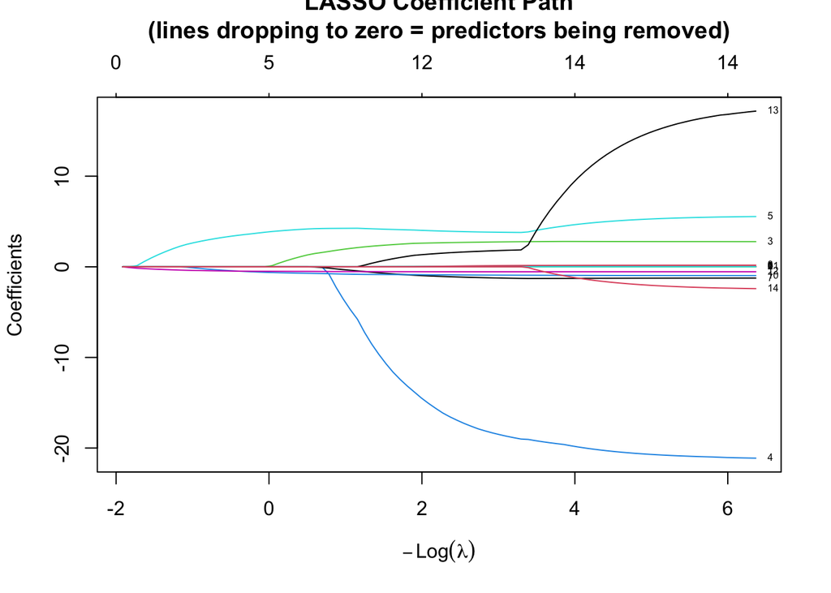

```r
set.seed(42)
lasso_model <- glmnet(x, y, alpha = 1)   # alpha = 1 means LASSO (alpha = 0 = Ridge)

# Coefficient path plot
# Each line = one predictor; as lambda increases, lines drop to zero
plot(lasso_model, xvar = "lambda", label = TRUE)
title("LASSO Coefficient Path\n(lines dropping to zero = predictors being removed)", line = 2.5)
```

## Step 3: Choose the Best Lambda Using Cross-Validation

We don’t pick $\lambda$ manually — we use **10-fold cross-validation** to find the $\lambda$ that gives the lowest prediction error.

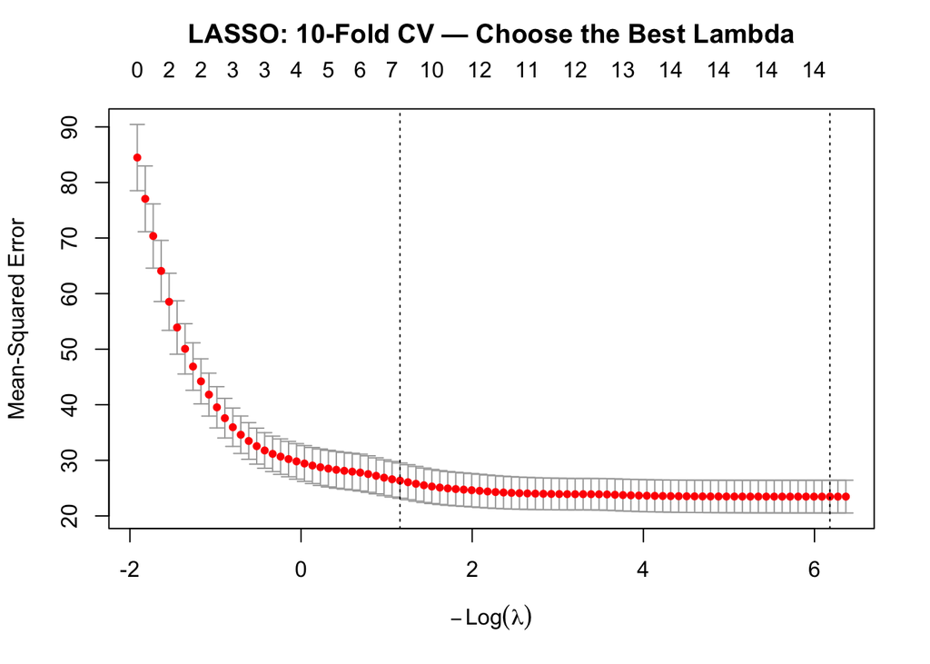

```r
set.seed(42)
cv_lasso <- cv.glmnet(x, y, alpha = 1, nfolds = 10)

plot(cv_lasso)
title("LASSO: 10-Fold CV — Choose the Best Lambda", line = 2.5)
```

```r
# Show the two key lambda values
data.frame(
  Lambda_Choice = c("lambda.min (best accuracy)", "lambda.1se (simplest good model)"),
  Lambda_Value  = round(c(cv_lasso$lambda.min, cv_lasso$lambda.1se), 4),
  row.names     = NULL
)
```

```
##                      Lambda_Choice Lambda_Value
## 1       lambda.min (best accuracy)       0.0021
## 2 lambda.1se (simplest good model)       0.3146
```

**Two common choices:**

- **`lambda.min`** — keeps more predictors, best raw prediction accuracy
- **`lambda.1se`** — keeps fewer predictors, simpler and more interpretable (preferred when simplicity matters)

## Step 4: See Which Predictors Survive

Here we extract the LASSO coefficients and display them in an easy-to-read table. A coefficient of zero means LASSO **removed** that predictor — it decided it wasn’t useful enough to justify the penalty.

```r
# --- Coefficients at lambda.min ---
coef_min <- coef(cv_lasso, s = "lambda.min")
coef_min_df <- data.frame(
  Predictor   = rownames(coef_min),
  Coefficient = round(as.numeric(coef_min), 4),
  Kept        = ifelse(as.numeric(coef_min) != 0, "Yes", "REMOVED"),
  row.names   = NULL
)

paste("=== LASSO Coefficients at lambda.min ===")
```

```
## [1] "=== LASSO Coefficients at lambda.min ==="
```

```r
coef_min_df
```

```
##                  Predictor Coefficient Kept
## 1              (Intercept)     25.6327  Yes
## 2                       zn      0.0276  Yes
## 3                    indus      0.0391  Yes
## 4                     chas      2.7781  Yes
## 5                      nox    -21.0876  Yes
## 6                       rm      5.5272  Yes
## 7                      age     -0.0019  Yes
## 8                      dis     -1.2465  Yes
## 9                      rad      0.1813  Yes
## 10                     tax     -0.0103  Yes
## 11                 ptratio     -0.9721  Yes
## 12                   black      0.0109  Yes
## 13                   lstat     -0.5419  Yes
## 14    high_crimeHigh Crime     17.0105  Yes
## 15 rm:high_crimeHigh Crime     -2.3820  Yes
```

```r
# --- Coefficients at lambda.1se ---
coef_1se <- coef(cv_lasso, s = "lambda.1se")
coef_1se_df <- data.frame(
  Predictor   = rownames(coef_1se),
  Coefficient = round(as.numeric(coef_1se), 4),
  Kept        = ifelse(as.numeric(coef_1se) != 0, "Yes", "REMOVED"),
  row.names   = NULL
)

paste("=== LASSO Coefficients at lambda.1se ===")
```

```
## [1] "=== LASSO Coefficients at lambda.1se ==="
```

```r
coef_1se_df
```

```
##                  Predictor Coefficient    Kept
## 1              (Intercept)     19.9040     Yes
## 2                       zn      0.0000 REMOVED
## 3                    indus      0.0000 REMOVED
## 4                     chas      2.1197     Yes
## 5                      nox     -5.7838     Yes
## 6                       rm      4.2554     Yes
## 7                      age      0.0000 REMOVED
## 8                      dis     -0.4481     Yes
## 9                      rad      0.0000 REMOVED
## 10                     tax      0.0000 REMOVED
## 11                 ptratio     -0.8287     Yes
## 12                   black      0.0073     Yes
## 13                   lstat     -0.5269     Yes
## 14    high_crimeHigh Crime      0.0000 REMOVED
## 15 rm:high_crimeHigh Crime      0.0000 REMOVED
```

```r
# --- Summary: which predictors survived at lambda.1se? ---
survived <- coef_1se_df %>%
  filter(Kept == "Yes", Predictor != "(Intercept)")

removed <- coef_1se_df %>%
  filter(Kept == "REMOVED")

paste("Predictors KEPT at lambda.1se:", paste(survived$Predictor, collapse = ", "))
```

```
## [1] "Predictors KEPT at lambda.1se: chas, nox, rm, dis, ptratio, black, lstat"
```

```r
paste("Predictors REMOVED at lambda.1se:", paste(removed$Predictor, collapse = ", "))
```

```
## [1] "Predictors REMOVED at lambda.1se: zn, indus, age, rad, tax, high_crimeHigh Crime, rm:high_crimeHigh Crime"
```

**How to interpret this table:**

- **Kept = “Yes”** → LASSO decided this predictor is important enough to stay in the model
- **Kept = “REMOVED”** → LASSO shrunk this predictor’s coefficient to exactly zero (it was not useful enough)
- The `Coefficient` column shows the shrunk (penalized) value — these are slightly biased toward zero compared to OLS, which is the trade-off LASSO makes for better prediction